# NFL Data Bowl Competition

Sarah Larson, Caitlin Robel, Noe Goldhaber, Alexis Hunting

2025-11-20

### 1. Introduction and Problem Motivation

Player-tracking data has transformed modern football analytics by enabling frame-level analysis of movement, positioning, and interaction between skill players and defenders. However, most separation-based statistics—both in public analytics and team scouting contexts—measure receiver separation only at a single point in time, typically at the moment of the catch (for completions) or at throw release. These measures ignore a critical component of receiver–defender interaction: the change in separation while the ball is in the air. Receivers may accelerate away from defenders, defenders may close aggressively, and route leverage may evolve in ways that have meaningful influence on play outcomes.

**Our central question:** How much separation does a receiver gain (or lose) while the ball is in the air—and what factors explain that gain?

This report introduces and analyzes In-Air Separation Gain (IASG), a metric designed to quantify the change in receiver–defender separation between the throw frame and the catch (or arrival) frame. IASG isolates mid-play separation dynamics that traditional metrics overlook. The central objective of this study is to determine how IASG varies across route types, coverage schemes, pass depths, offensive teams, and defensive units, and to assess how strongly IASG contributes to completion probability and overall play value.

**IASG=Separation at Arrival−Separation at Throw**

A positive IASG means the WR gets more open while the ball is traveling. A negative IASG means the defender closes the gap. This metric is interesting because it isolates receiver skill during the ball’s flight—not just route running, captures defender pursuit quality and closing speed, links directly to completion probability and expected points, and can help identify undervalued receivers and defensive units.

To produce player-level evaluations, the study extends IASG into a second metric: Separation Added Over Expectation (SAOE). This is defined as the difference between a receiver’s observed IASG and the IASG predicted by a multivariate linear model that accounts for route, coverage type, pass depth, defensive structure, and quarterback dropback type. SAOE therefore measures how much separation a player creates—or loses—relative to what the play design and situation would typically generate. Together, IASG and SAOE offer a new lens for evaluating receiver performance and defensive closing ability.

**SAOE = IASG − IASG(expected)**

The remainder of this report describes the dataset and modeling process, outlines the computational steps used to derive the new metrics, and presents the findings in the context of both individual players and team-level performance. Limitations and directions for future refinement conclude the report.

### 2. Data and Methods

The dataset consists of all eighteen weeks of the 2023 NFL Big Data Bowl tracking files, including both input tracking files (which contain player positions and identifiers for each frame prior to the throw) and output tracking files (which describe receiver and defender positions from the ball’s release to its arrival). Supplementary play-level information provides route labels, coverage types, expected points added (EPA), pass depth, formation information, and team identifiers.

After row-binding all weekly files into comprehensive input and output datasets, the analysis identifies the targeted receiver for each play using the tracking designation “Targeted Receiver.” For each play, the throw frame is defined as the final frame in the input file for that play, and the arrival frame is the final frame in the output file. At each of these frames, the minimum Euclidean distance between the targeted receiver and any defender is computed; these values are denoted as separation at throw (sep_t0) and separation at arrival (sep_t1). IASG is computed as the difference sep_t1 − sep_t0.

Next, IASG is merged with supplementary data to create a complete play-level dataset containing route type, coverage classification (man versus zone), pass result, EPA, pass depth, dropback type, and other contextual variables. This enriched dataset supports both summary analysis and formal modeling.

To estimate the expected IASG given play context, a linear model is fit using IASG as the response and the following predictors: route of the targeted receiver, man/zone coverage, pass length in yards, number of defenders in the box, and quarterback dropback type. The fitted values from this model represent the expected IASG for each play. SAOE is then defined as the observed IASG minus its model-based expectation, producing a context-adjusted measure of separation gain.

Finally, the analysis computes a WR Advantage Score, defined as the multiplicative interaction between IASG and EPA (IASG × EPA). This quantity captures how much in-air separation contributes to overall play value, rather than treating separation dynamics as independent of down-and-distance context.

```r
supp_data = read.csv("supplementary_data.csv")

for (i in 1:18) {
  wk <- sprintf("%02d", i)

  df <- read.csv(
    paste0(
      "/Users/sarahlarson/Downloads/sports stats/114239_nfl_competition_files_published_analytics_final/train/input_2023_w",
      wk,
      ".csv"
    )
  )



  assign(paste0("week", wk, "_input_train"), df)
}

for (i in 1:18) {
  wk <- sprintf("%02d", i)

  df <- read.csv(
    paste0(
      "/Users/sarahlarson/Downloads/sports stats/114239_nfl_competition_files_published_analytics_final/train/output_2023_w",
      wk,
      ".csv"
    )
  )

  assign(paste0("week", wk, "_output_train"), df)
}
```

```r
input_names  <- sprintf("week%02d_input_train", 1:18)
output_names <- sprintf("week%02d_output_train", 1:18)

input_df <- bind_rows(mget(input_names))

# combining all outputs into one big data frame
output_df <- bind_rows(mget(output_names))
```

```r
roster_df <- input_df %>%
  distinct(game_id, play_id, nfl_id, player_side, player_role)

output_df <- output_df %>%
  left_join(roster_df, by = c("game_id", "play_id", "nfl_id"))
```

```r
# which player is the targeted WR on each play
targets <- input_df %>%
  filter(player_role == "Targeted Receiver") %>%
  distinct(game_id, play_id, wr_nfl_id = nfl_id)

# frame of the THROW = last frame in input
throw_frames <- input_df %>%
  group_by(game_id, play_id) %>%
  summarise(throw_frame = max(frame_id), .groups = "drop")

# frame of the CATCH / arrival = last frame in output
catch_frames <- output_df %>%
  group_by(game_id, play_id) %>%
  summarise(catch_frame = max(frame_id), .groups = "drop")
```

```r
# WR position at throw
wr_throw <- input_df %>%
  inner_join(targets, by = c("game_id", "play_id", "nfl_id" = "wr_nfl_id")) %>%
  inner_join(throw_frames, by = c("game_id", "play_id")) %>%
  filter(frame_id == throw_frame) %>%
  transmute(game_id, play_id, wr_nfl_id = nfl_id,
            wr_x0 = x, wr_y0 = y)

# defenders at throw
def_throw <- input_df %>%
  inner_join(throw_frames, by = c("game_id", "play_id")) %>%
  filter(frame_id == throw_frame,
         player_side == "Defense") %>%
  transmute(game_id, play_id,
            def_nfl_id = nfl_id,
            def_x0 = x, def_y0 = y)

# separation at throw = min distance to any defender
sep_throw <- def_throw %>%
  inner_join(wr_throw, by = c("game_id", "play_id")) %>%
  mutate(dist0 = sqrt((wr_x0 - def_x0)^2 + (wr_y0 - def_y0)^2)) %>%
  group_by(game_id, play_id, wr_nfl_id) %>%
  summarise(sep_t0 = min(dist0, na.rm = TRUE), .groups = "drop")
```

```r
# WR position at catch frame
wr_catch <- output_df %>%
  inner_join(targets, by = c("game_id", "play_id", "nfl_id" = "wr_nfl_id")) %>%
  inner_join(catch_frames, by = c("game_id", "play_id")) %>%
  filter(frame_id == catch_frame) %>%
  transmute(game_id, play_id, wr_nfl_id = nfl_id,
            wr_x1 = x, wr_y1 = y)

# defenders at catch frame
def_catch <- output_df %>%
  inner_join(catch_frames, by = c("game_id", "play_id")) %>%
  filter(frame_id == catch_frame,
         player_side == "Defense") %>%
  transmute(game_id, play_id,
            def_nfl_id = nfl_id,
            def_x1 = x, def_y1 = y)

# separation at catch = min distance to any defender
sep_catch <- def_catch %>%
  inner_join(wr_catch, by = c("game_id", "play_id")) %>%
  mutate(dist1 = sqrt((wr_x1 - def_x1)^2 + (wr_y1 - def_y1)^2)) %>%
  group_by(game_id, play_id, wr_nfl_id) %>%
  summarise(sep_t1 = min(dist1, na.rm = TRUE), .groups = "drop")
```

```r
# In-Air Separation Gain
iasg_df <- sep_throw %>%
  inner_join(sep_catch, by = c("game_id", "play_id", "wr_nfl_id")) %>%
  mutate(IASG = sep_t1 - sep_t0)

# bring in supplementary data (routes, coverage, pass_result, etc.)
plays_enriched <- iasg_df %>%
  inner_join(supp_data, by = c("game_id", "play_id")) %>%
  select(game_id, play_id, wr_nfl_id,
         route_of_targeted_receiver,
         team_coverage_man_zone,
         pass_result,
         sep_t0, sep_t1, IASG,
         everything())
```

```r
plays_enriched %>%
  group_by(route_of_targeted_receiver, team_coverage_man_zone) %>%
  summarise(
    n = n(),
    mean_IASG = mean(IASG, na.rm = TRUE),
    mean_sep_t0 = mean(sep_t0, na.rm = TRUE),
    mean_sep_t1 = mean(sep_t1, na.rm = TRUE)
  ) %>%
  arrange(desc(mean_IASG))
```

```
## # A tibble: 27 × 6
## # Groups:   route_of_targeted_receiver [13]
##    route_of_targeted_receiver team_coverage_man_zone     n mean_IASG mean_sep_t0
##    <chr>                      <chr>                  <int>     <dbl>       <dbl>
##  1 <NA>                       ZONE_COVERAGE              1    0.599        3.24
##  2 CORNER                     MAN_COVERAGE             219    0.361        2.02
##  3 POST                       MAN_COVERAGE             191    0.0896       1.87
##  4 WHEEL                      MAN_COVERAGE              32    0.0500       2.09
##  5 CROSS                      MAN_COVERAGE             564   -0.0516       2.77
##  6 OUT                        MAN_COVERAGE             621   -0.245        2.56
##  7 GO                         MAN_COVERAGE             552   -0.288        1.69
##  8 POST                       ZONE_COVERAGE            578   -0.390        3.20
##  9 OUT                        <NA>                       1   -0.408        0.911
## 10 IN                         MAN_COVERAGE             320   -0.413        2.37
## # ℹ 17 more rows
## # ℹ 1 more variable: mean_sep_t1 <dbl>
```

```r
plays_clean <- plays_enriched %>%
  filter(
    !is.na(IASG),
    !is.na(route_of_targeted_receiver),
    !is.na(team_coverage_man_zone)
  )

route_cov_summary <- plays_clean %>%
  mutate(
    coverage_simple = case_when(
      team_coverage_man_zone == "MAN_COVERAGE"  ~ "Man",
      team_coverage_man_zone == "ZONE_COVERAGE" ~ "Zone",
      TRUE ~ team_coverage_man_zone
    )
  ) %>%
  group_by(route_of_targeted_receiver, coverage_simple) %>%
  summarise(
    n         = n(),
    mean_IASG = mean(IASG, na.rm = TRUE),
    mean_sep_t0 = mean(sep_t0, na.rm = TRUE),
    mean_sep_t1 = mean(sep_t1, na.rm = TRUE),
    .groups = "drop"
  ) %>%
  filter(n >= 150) %>%
  arrange(desc(mean_IASG))
```

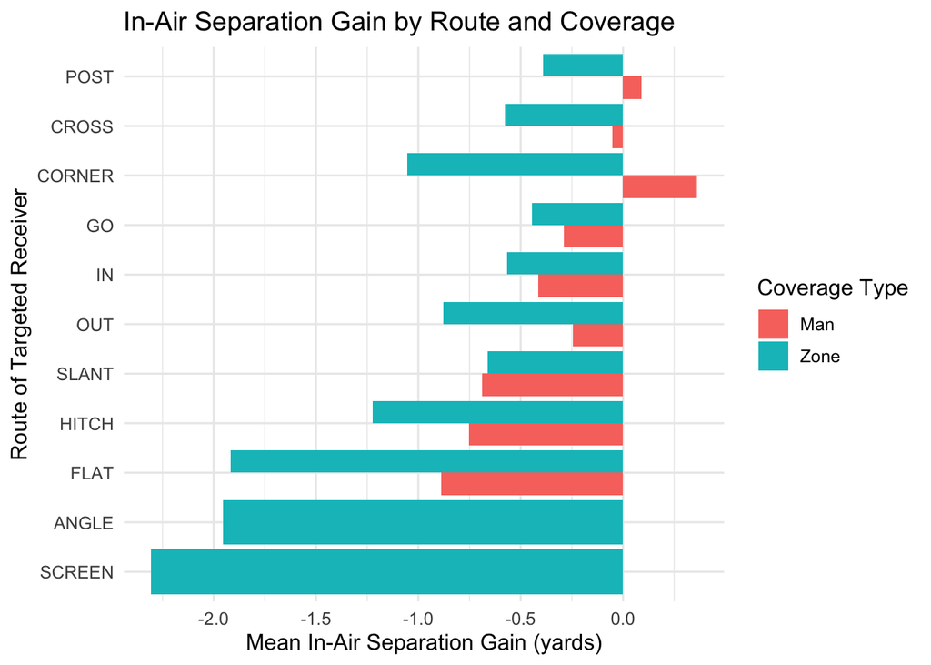

```r
ggplot(route_cov_summary,
       aes(x = reorder(route_of_targeted_receiver, mean_IASG),
           y = mean_IASG,
           fill = coverage_simple)) +
  geom_col(position = "dodge") +
  coord_flip() +
  labs(
    title = "In-Air Separation Gain by Route and Coverage",
    x = "Route of Targeted Receiver",
    y = "Mean In-Air Separation Gain (yards)",
    fill = "Coverage Type"
  ) +
  theme_minimal(base_size = 12)
```

```r
plays_enriched <- plays_enriched %>%
  mutate(
    complete = ifelse(pass_result == "C", 1, 0),
    team_coverage_man_zone = as.factor(team_coverage_man_zone)
  )

completion_model <- glm(
  complete ~ IASG + team_coverage_man_zone,
  data = plays_enriched,
  family = binomial
)

summary(completion_model)
```

```
##
## Call:
## glm(formula = complete ~ IASG + team_coverage_man_zone, family = binomial,
##     data = plays_enriched)
##
## Coefficients:
##                                     Estimate Std. Error z value Pr(>|z|)
## (Intercept)                         0.386652   0.032849  11.771  < 2e-16 ***
## IASG                                0.033124   0.009391   3.527  0.00042 ***
## team_coverage_man_zoneZONE_COVERAGE 0.510537   0.040433  12.627  < 2e-16 ***
## ---
## Signif. codes:  0 '***' 0.001 '**' 0.01 '*' 0.05 '.' 0.1 ' ' 1
##
## (Dispersion parameter for binomial family taken to be 1)
##
##     Null deviance: 16444  on 12963  degrees of freedom
## Residual deviance: 16283  on 12961  degrees of freedom
##   (2 observations deleted due to missingness)
## AIC: 16289
##
## Number of Fisher Scoring iterations: 4
```

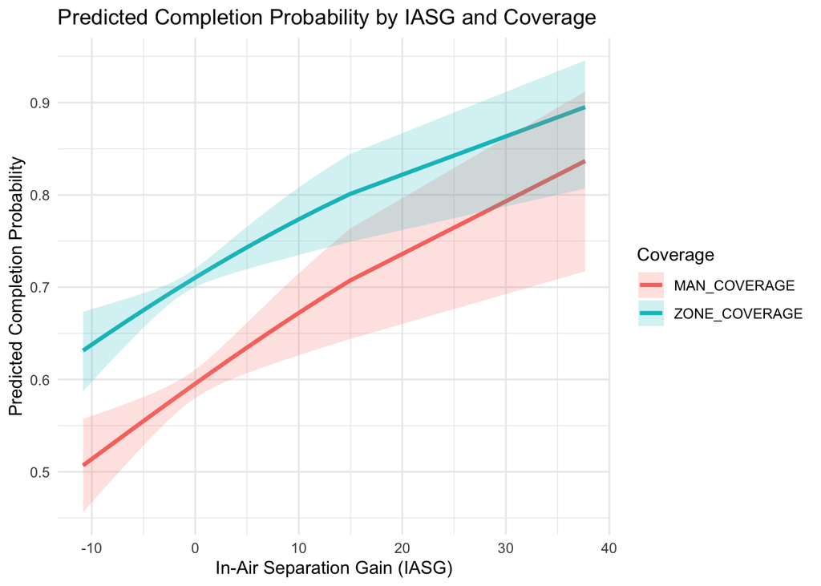

```r
pred <- ggpredict(completion_model, terms = c("IASG [all]", "team_coverage_man_zone")) %>%
  as.data.frame() %>%
  rename(
    IASG = x,
    predicted = predicted,
    conf_low = conf.low,
    conf_high = conf.high,
    coverage = group
  )

# Plot
ggplot(pred, aes(x = IASG, y = predicted, color = coverage)) +
  geom_line(size = 1.2) +
  geom_ribbon(aes(x = IASG, ymin = conf_low, ymax = conf_high, fill = coverage),
              alpha = 0.2, inherit.aes = FALSE) +
  labs(
    title = "Predicted Completion Probability by IASG and Coverage",
    x = "In-Air Separation Gain (IASG)",
    y = "Predicted Completion Probability",
    color = "Coverage",
    fill = "Coverage"
  ) +
  theme_minimal()
```

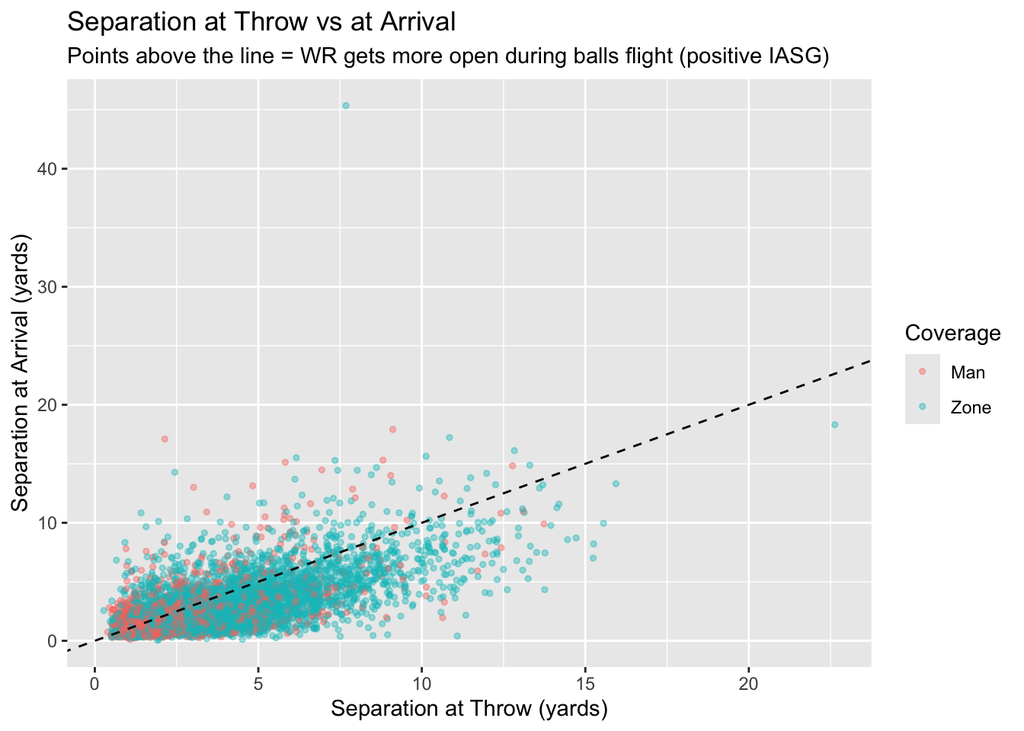

```r
set.seed(310)

plays_sample <- plays_clean %>%
  sample_n(size = min(5000, n())) %>%
  mutate(
    coverage_simple = case_when(
      team_coverage_man_zone == "MAN_COVERAGE"  ~ "Man",
      team_coverage_man_zone == "ZONE_COVERAGE" ~ "Zone",
      TRUE ~ team_coverage_man_zone
    )
  )

ggplot(plays_sample,
       aes(x = sep_t0,
           y = sep_t1,
           color = coverage_simple)) +
  geom_point(alpha = 0.4, size = 1) +
  geom_abline(slope = 1, intercept = 0, linetype = "dashed") +
  labs(
    title = "Separation at Throw vs at Arrival",
    subtitle = "Points above the line = WR gets more open during balls flight (positive IASG)",
    x = "Separation at Throw (yards)",
    y = "Separation at Arrival (yards)",
    color = "Coverage"
  )
```

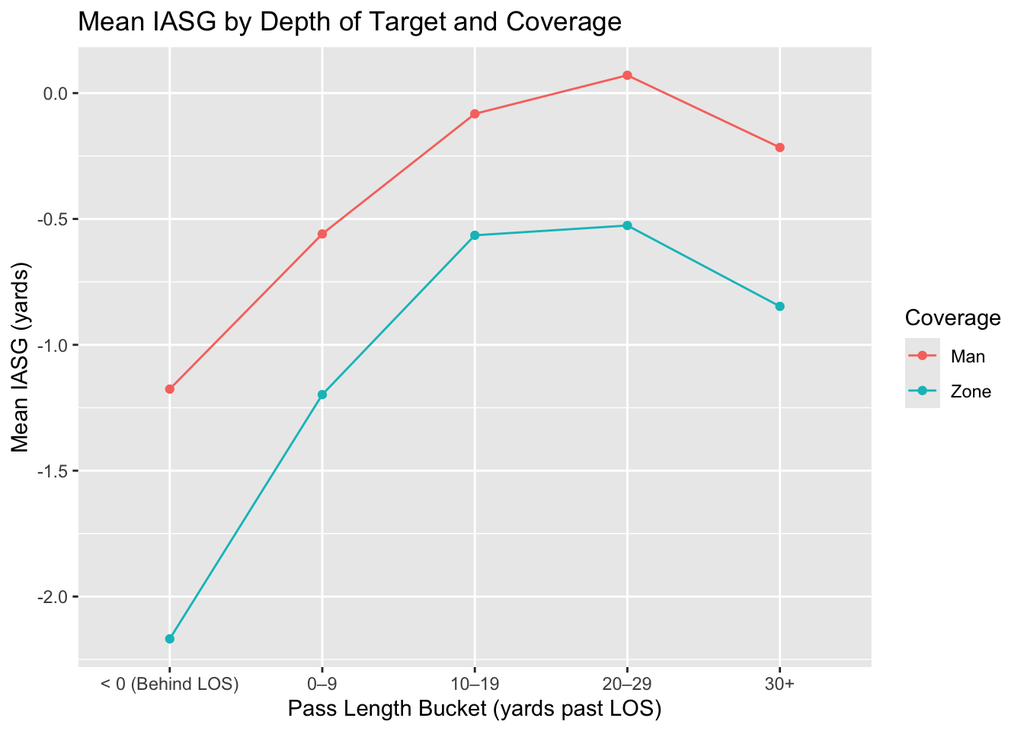

```r
plays_depth <- plays_clean %>%
  mutate(
    pass_len_bucket = case_when(
      pass_length < 0              ~ "< 0 (Behind LOS)",
      pass_length >= 0 & pass_length < 10  ~ "0–9",
      pass_length >= 10 & pass_length < 20 ~ "10–19",
      pass_length >= 20 & pass_length < 30 ~ "20–29",
      pass_length >= 30                   ~ "30+",
      TRUE ~ "Unknown"
    ),
    coverage_simple = case_when(
      team_coverage_man_zone == "MAN_COVERAGE"  ~ "Man",
      team_coverage_man_zone == "ZONE_COVERAGE" ~ "Zone",
      TRUE ~ team_coverage_man_zone
    )
  )

depth_summary <- plays_depth %>%
  filter(pass_len_bucket != "Unknown") %>%
  group_by(pass_len_bucket, coverage_simple) %>%
  summarise(
    n = n(),
    mean_IASG = mean(IASG, na.rm = TRUE),
    .groups = "drop"
  )

ggplot(depth_summary,
       aes(x = pass_len_bucket,
           y = mean_IASG,
           group = coverage_simple,
           color = coverage_simple)) +
  geom_line() +
  geom_point() +
  labs(
    title = "Mean IASG by Depth of Target and Coverage",
    x = "Pass Length Bucket (yards past LOS)",
    y = "Mean IASG (yards)",
    color = "Coverage"
  )
```

```r
## Team-level IASG: offense

offense_summary <- plays_clean %>%
  group_by(possession_team) %>%
  summarise(
    n = n(),
    mean_IASG = mean(IASG, na.rm = TRUE),
    .groups = "drop"
  ) %>%
  filter(n >= 50) %>%           # drop tiny-sample teams if needed
  arrange(desc(mean_IASG))

offense_summary
```

```
## # A tibble: 32 × 3
##    possession_team     n mean_IASG
##    <chr>           <int>     <dbl>
##  1 TB                403    -0.609
##  2 LA                418    -0.624
##  3 BUF               417    -0.646
##  4 SF                371    -0.658
##  5 DAL               479    -0.658
##  6 LAC               451    -0.669
##  7 DET               448    -0.674
##  8 IND               415    -0.692
##  9 NYG               372    -0.702
## 10 BAL               362    -0.702
## # ℹ 22 more rows
```

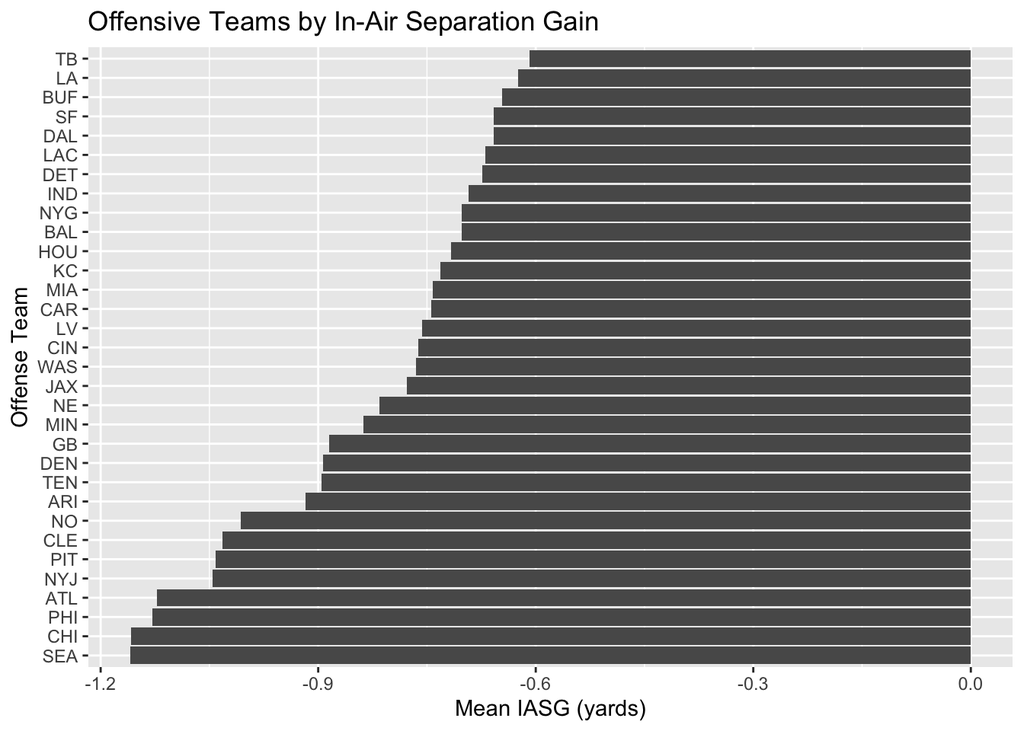

```r
ggplot(offense_summary,
       aes(x = reorder(possession_team, mean_IASG),
           y = mean_IASG)) +
  geom_col() +
  coord_flip() +
  labs(
    title = "Offensive Teams by In-Air Separation Gain",
    x = "Offense Team",
    y = "Mean IASG (yards)"
  )
```

```r
## Team-level IASG: defense

defense_summary <- plays_clean %>%
  group_by(defensive_team) %>%
  summarise(
    n = n(),
    mean_IASG_allowed = mean(IASG, na.rm = TRUE),
    .groups = "drop"
  ) %>%
  filter(n >= 50) %>%
  arrange(mean_IASG_allowed)    # low = good defense

defense_summary
```

```
## # A tibble: 32 × 3
##    defensive_team     n mean_IASG_allowed
##    <chr>          <int>             <dbl>
##  1 CAR              324            -1.18
##  2 MIN              389            -1.17
##  3 CHI              446            -1.12
##  4 SF               437            -0.982
##  5 HOU              399            -0.955
##  6 NYG              412            -0.947
##  7 CIN              412            -0.937
##  8 ARI              348            -0.932
##  9 LAC              426            -0.929
## 10 LV               360            -0.927
## # ℹ 22 more rows
```

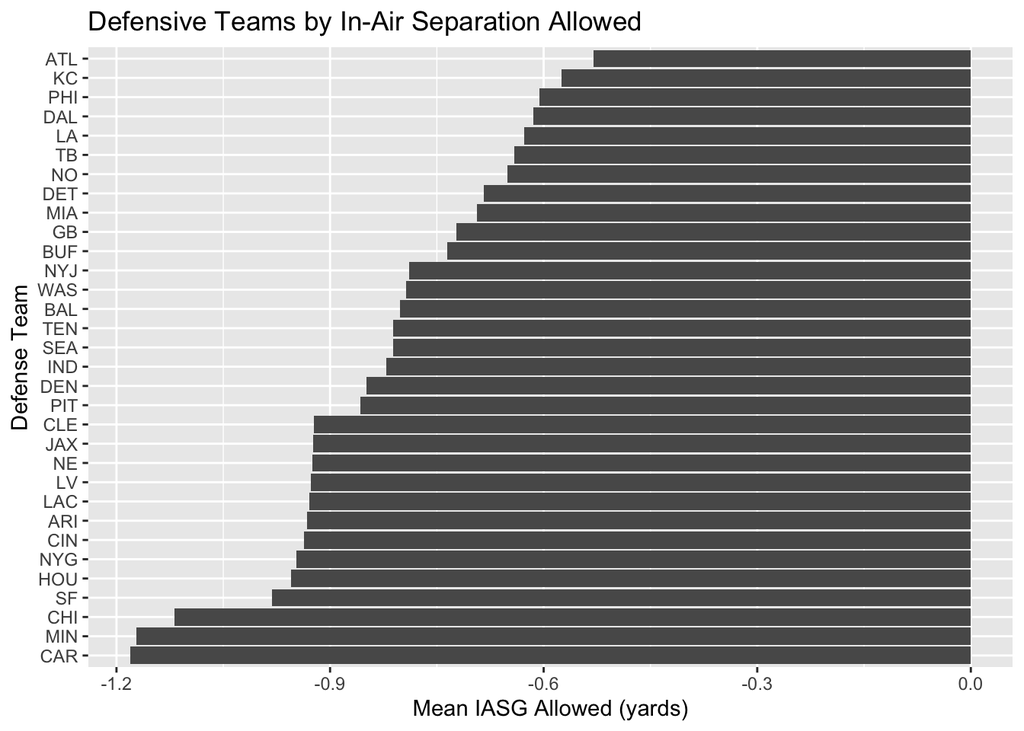

```r
ggplot(defense_summary,
       aes(x = reorder(defensive_team, mean_IASG_allowed),
           y = mean_IASG_allowed)) +
  geom_col() +
  coord_flip() +
  labs(
    title = "Defensive Teams by In-Air Separation Allowed",
    x = "Defense Team",
    y = "Mean IASG Allowed (yards)"
  )
```

Team-level summaries reveal that offenses such as Tampa Bay, the Los Angeles Rams, Buffalo, Dallas, and San Francisco create the highest average IASG across their targeted pass plays. By contrast, teams such as Seattle, Chicago, Philadelphia, and Atlanta create the lowest IASG, suggesting that their receivers struggle to generate additional separation after the throw relative to the rest of the league.

Defensively, Chicago, Minnesota, San Francisco, and Carolina allow the lowest IASG, indicating strong downstream coverage and pursuit. Conversely, Kansas City, Philadelphia, Dallas, and Atlanta allow relatively high IASG values, reflecting challenges in maintaining separation control once the ball is released.

```r
plays_adv <- plays_clean %>%
  filter(!is.na(expected_points_added)) %>%
  mutate(
    WR_advantage = IASG * expected_points_added
  )

adv_route_cov <- plays_adv %>%
  mutate(
    coverage_simple = case_when(
      team_coverage_man_zone == "MAN_COVERAGE"  ~ "Man",
      team_coverage_man_zone == "ZONE_COVERAGE" ~ "Zone",
      TRUE ~ team_coverage_man_zone
    )
  ) %>%
  group_by(route_of_targeted_receiver, coverage_simple) %>%
  summarise(
    n = n(),
    mean_WR_adv = mean(WR_advantage, na.rm = TRUE),
    .groups = "drop"
  ) %>%
  filter(n >= 30) %>%
  arrange(desc(mean_WR_adv))

adv_route_cov
```

```
## # A tibble: 24 × 4
##    route_of_targeted_receiver coverage_simple     n mean_WR_adv
##    <chr>                      <chr>           <int>       <dbl>
##  1 FLAT                       Zone             1096       1.03
##  2 SCREEN                     Zone              153       0.836
##  3 WHEEL                      Zone               44       0.804
##  4 WHEEL                      Man                32       0.786
##  5 ANGLE                      Zone              332       0.716
##  6 CROSS                      Zone              754       0.701
##  7 CORNER                     Man               219       0.587
##  8 CORNER                     Zone              289       0.542
##  9 GO                         Zone              841       0.535
## 10 OUT                        Man               621       0.505
## # ℹ 14 more rows
```

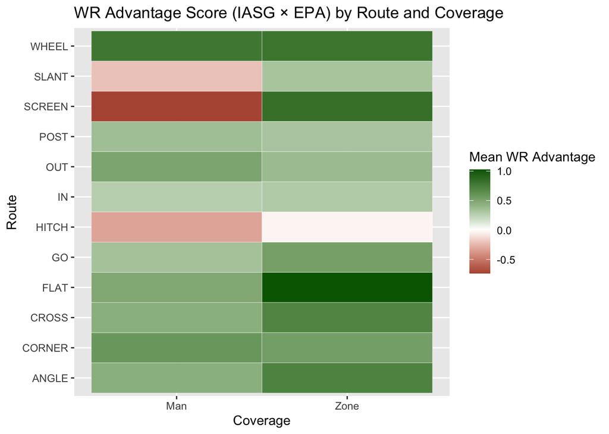

```r
ggplot(adv_route_cov,
       aes(x = coverage_simple,
           y = route_of_targeted_receiver,
           fill = mean_WR_adv)) +
  geom_tile(color = "white") +
  scale_fill_gradient2(
    low = "darkred",
    mid = "white",
    high = "darkgreen",
    midpoint = 0
  ) +
  labs(
    title = "WR Advantage Score (IASG × EPA) by Route and Coverage",
    x = "Coverage",
    y = "Route",
    fill = "Mean WR Advantage"
  )
```

This heatmap presents the WR Advantage Score—IASG multiplied by EPA—summarizing how valuable mid-air separation is for each route under man and zone coverage. Several patterns stand out. Wheel routes produce strong positive advantage in both coverages, reflecting their ability to create separation and generate high-value gains. Screens show a sharp split: highly negative in man coverage, where defenders close quickly, but strongly positive in zone coverage, where receivers can exploit space. Short and timing-based routes such as slants, hitches, and ins generally produce low or slightly negative advantage in man coverage, while their zone values rise toward neutral or mildly positive. Vertical and space-attacking concepts—corner, post, go, and cross—tend to yield consistent positive advantage scores across both coverages. Overall, the heatmap shows that the value of in-air separation varies substantially by route–coverage combination, with certain concepts (wheel, screen vs zone, flat vs zone) offering notably higher offensive upside.

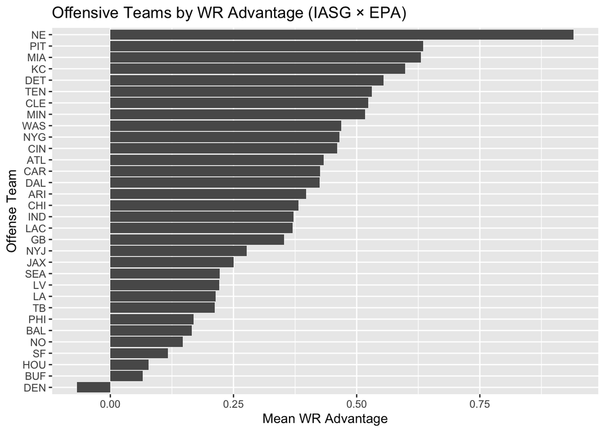

```r
offense_adv <- plays_adv %>%
  group_by(possession_team) %>%
  summarise(
    n = n(),
    mean_WR_adv = mean(WR_advantage, na.rm = TRUE),
    .groups = "drop"
  ) %>%
  filter(n >= 50) %>%
  arrange(desc(mean_WR_adv))

ggplot(offense_adv,
       aes(x = reorder(possession_team, mean_WR_adv),
           y = mean_WR_adv)) +
  geom_col() +
  coord_flip() +
  labs(
    title = "Offensive Teams by WR Advantage (IASG × EPA)",
    x = "Offense Team",
    y = "Mean WR Advantage"
  )
```

This graph ranks all NFL offenses by their WR Advantage Score, which combines in-air separation gain (IASG) with the play’s expected points added (EPA) to measure how effectively each team converts mid-air separation into real offensive value. The results show substantial variation across the league. New England, Pittsburgh, and Miami lead the NFL, indicating that their receivers generate separation in situations that meaningfully boost play value. Teams like Kansas City, Detroit, and Tennessee also grade highly, reflecting efficient route concepts and strong timing between quarterbacks and receivers. On the lower end, offenses such as Denver, Buffalo, and Houston generate little to no positive WR advantage, suggesting either limited mid-air separation or that the separation they do create is not translating into high-value outcomes. Overall, this chart highlights which offenses maximize separation into production and which struggle to turn space into EPA.

```r
plays_model <- plays_clean %>%
  filter(
    !is.na(IASG),
    !is.na(route_of_targeted_receiver),
    !is.na(team_coverage_man_zone),
    !is.na(pass_length),
    !is.na(defenders_in_the_box),
    !is.na(dropback_type)
  ) %>%
  mutate(
    route_of_targeted_receiver = as.factor(route_of_targeted_receiver),
    team_coverage_man_zone     = as.factor(team_coverage_man_zone),
    dropback_type              = as.factor(dropback_type)
  )


iasg_model <- lm(
  IASG ~ route_of_targeted_receiver +
    team_coverage_man_zone +
    pass_length +
    defenders_in_the_box +
    dropback_type,
  data = plays_model
)

summary(iasg_model)
```

```
##
## Call:
## lm(formula = IASG ~ route_of_targeted_receiver + team_coverage_man_zone +
##     pass_length + defenders_in_the_box + dropback_type, data = plays_model)
##
## Residuals:
##     Min      1Q  Median      3Q     Max
## -10.843  -1.112  -0.023   0.974  40.000
##
## Coefficients:
##                                      Estimate Std. Error t value Pr(>|t|)
## (Intercept)                         -1.442794   0.205871  -7.008 2.53e-12 ***
## route_of_targeted_receiverCORNER     1.035105   0.143329   7.222 5.41e-13 ***
## route_of_targeted_receiverCROSS      1.177996   0.118271   9.960  < 2e-16 ***
## route_of_targeted_receiverFLAT       0.031547   0.115111   0.274  0.78405
## route_of_targeted_receiverGO         1.112980   0.128355   8.671  < 2e-16 ***
## route_of_targeted_receiverHITCH      0.599511   0.109757   5.462 4.79e-08 ***
## route_of_targeted_receiverIN         1.143707   0.120210   9.514  < 2e-16 ***
## route_of_targeted_receiverOUT        0.966807   0.111541   8.668  < 2e-16 ***
## route_of_targeted_receiverPOST       1.328736   0.133368   9.963  < 2e-16 ***
## route_of_targeted_receiverSCREEN    -0.365604   0.177052  -2.065  0.03895 *
## route_of_targeted_receiverSLANT      0.945190   0.120556   7.840 4.85e-15 ***
## route_of_targeted_receiverWHEEL      1.188402   0.252400   4.708 2.52e-06 ***
## team_coverage_man_zoneZONE_COVERAGE -0.499581   0.039249 -12.728  < 2e-16 ***
## pass_length                          0.007424   0.002621   2.833  0.00463 **
## defenders_in_the_box                 0.080591   0.018693   4.311 1.63e-05 ***
## dropback_typeDESIGNED_ROLLOUT_RIGHT -0.042784   0.152579  -0.280  0.77917
## dropback_typeSCRAMBLE               -0.437289   0.146371  -2.988  0.00282 **
## dropback_typeSCRAMBLE_ROLLOUT_LEFT  -1.435858   0.527699  -2.721  0.00652 **
## dropback_typeSCRAMBLE_ROLLOUT_RIGHT -1.143493   0.261984  -4.365 1.28e-05 ***
## dropback_typeTRADITIONAL            -0.421088   0.123302  -3.415  0.00064 ***
## ---
## Signif. codes:  0 '***' 0.001 '**' 0.01 '*' 0.05 '.' 0.1 ' ' 1
##
## Residual standard error: 1.989 on 12943 degrees of freedom
## Multiple R-squared:  0.07208,    Adjusted R-squared:  0.07072
## F-statistic: 52.91 on 19 and 12943 DF,  p-value: < 2.2e-16
```

```r
plays_model <- plays_model %>%
  mutate(
    IASG_exp = predict(iasg_model, newdata = .),
    SAOE     = IASG - IASG_exp
  )


plays_enriched <- plays_enriched %>%
  left_join(
    plays_model %>%
      select(game_id, play_id, wr_nfl_id, IASG_exp, SAOE),
    by = c("game_id", "play_id", "wr_nfl_id")
  )
```

```r
route_cov_saoe <- plays_model %>%
  mutate(
    coverage_simple = case_when(
      team_coverage_man_zone == "MAN_COVERAGE"  ~ "Man",
      team_coverage_man_zone == "ZONE_COVERAGE" ~ "Zone",
      TRUE ~ as.character(team_coverage_man_zone)
    )
  ) %>%
  group_by(route_of_targeted_receiver, coverage_simple) %>%
  summarise(
    n         = n(),
    mean_SAOE = mean(SAOE, na.rm = TRUE),
    .groups = "drop"
  ) %>%
  filter(n >= 30) %>%
  arrange(desc(mean_SAOE))

route_cov_saoe
```

```
## # A tibble: 24 × 4
##    route_of_targeted_receiver coverage_simple     n mean_SAOE
##    <fct>                      <chr>           <int>     <dbl>
##  1 ANGLE                      Man                48    0.631
##  2 CORNER                     Man               219    0.521
##  3 FLAT                       Man               366    0.351
##  4 SCREEN                     Man                37    0.305
##  5 SLANT                      Zone              571    0.240
##  6 GO                         Zone              841    0.132
##  7 WHEEL                      Man                32    0.118
##  8 IN                         Zone              776    0.0996
##  9 OUT                        Man               621    0.0780
## 10 CROSS                      Man               564    0.0138
## # ℹ 14 more rows
```

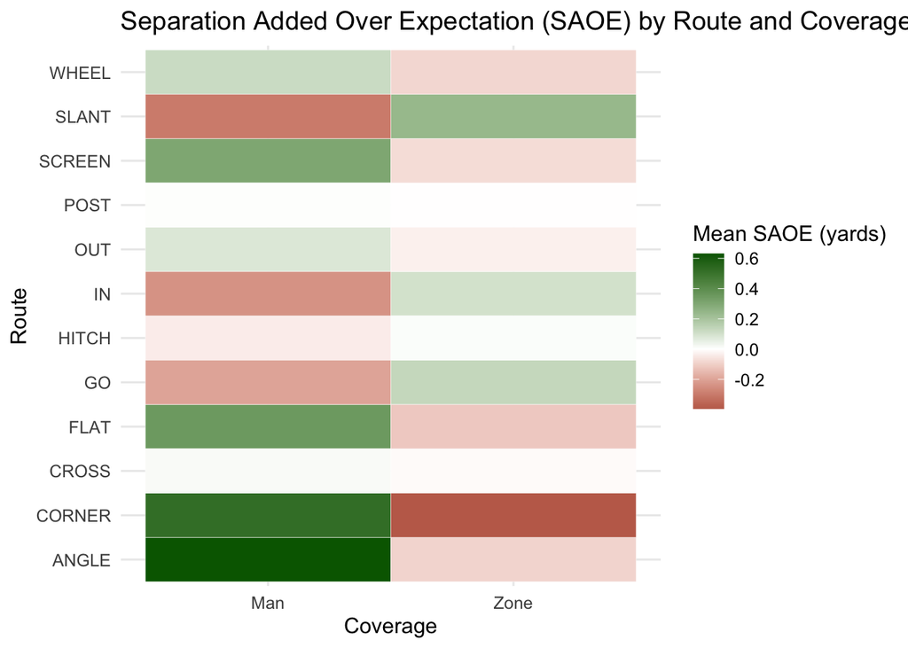

```r
ggplot(route_cov_saoe,
       aes(x = coverage_simple,
           y = route_of_targeted_receiver,
           fill = mean_SAOE)) +
  geom_tile(color = "white") +
  scale_fill_gradient2(
    low = "darkred",
    mid = "white",
    high = "darkgreen",
    midpoint = 0
  ) +
  labs(
    title = "Separation Added Over Expectation (SAOE) by Route and Coverage",
    x = "Coverage",
    y = "Route",
    fill = "Mean SAOE (yards)"
  ) +
  theme_minimal(base_size = 12)
```

```r
wr_saoe <- plays_model %>%
  group_by(wr_nfl_id) %>%
  summarise(
    n = n(),
    mean_SAOE = mean(SAOE, na.rm = TRUE),
    .groups = "drop"
  ) %>%
  filter(n >= 20) %>%   # require enough targets
  arrange(desc(mean_SAOE))


player_lookup <- input_df %>%
  distinct(nfl_id, player_name) %>%
  filter(!is.na(nfl_id), !is.na(player_name))

wr_saoe_named <- wr_saoe %>%
  left_join(player_lookup, by = c("wr_nfl_id" = "nfl_id")) %>%
  arrange(desc(mean_SAOE))

head(wr_saoe_named, 20)
```

```
## # A tibble: 20 × 4
##    wr_nfl_id     n mean_SAOE player_name
##        <int> <int>     <dbl> <chr>
##  1     46071    37     1.40  Saquon Barkley
##  2     43584    33     0.960 Kalif Raymond
##  3     48456    36     0.802 Donald Parham
##  4     52474    28     0.782 Antonio Gibson
##  5     44820    53     0.751 Christian McCaffrey
##  6     43663    24     0.708 Alex Erickson
##  7     47852    21     0.697 Josh Oliver
##  8     44927    26     0.610 Samaje Perine
##  9     52625    27     0.604 Jauan Jennings
## 10     54528    31     0.571 James Cook
## 11     48471    28     0.539 Trenton Irwin
## 12     47879    30     0.536 Dawson Knox
## 13     46522    20     0.531 Byron Pringle
## 14     53549    27     0.521 Rhamondre Stevenson
## 15     55944    78     0.514 Josh Downs
## 16     52584    63     0.514 K.J. Osborn
## 17     46094    29     0.478 Hayden Hurst
## 18     40011    90     0.469 Travis Kelce
## 19     40488   122     0.467 Adam Thielen
## 20     44881    79     0.464 Cooper Kupp
```

After adjusting for contextual factors in the IASG regression model, SAOE identifies individual players who consistently outperform expectation. The highest-graded players include Saquon Barkley, Kalif Raymond, Donald Parham, Antonio Gibson, and Christian McCaffrey. Although several of these players are running backs or hybrid personnel, their route types and usage patterns frequently place them in underneath matchups against linebackers or zone coverage defenders, enabling them to outperform the separation gains predicted by the model. The SAOE leaderboard underscores that separation excellence is not limited to traditional wide receivers and that certain players excel at creating unexpected space regardless of play design.

### Discussion

Our analysis provides a detailed look into how receivers create separation both at the catch point and while the ball is in flight, as well as how these movement-based advantages translate into play value. Across the league, we observe consistent negative mean In-Air Separation Gain (IASG), confirming that defenders generally close space after the ball is thrown. Still, meaningful variation exists across routes, coverage types, and teams, which highlights that IASG captures something real about receiver separation skill and defensive structure.

Team-level trends also illustrate systematic differences in passing structure. Offensively, teams like New England, Pittsburgh, and Miami create far more WR advantage (IASG × EPA), suggesting that their route concepts and timing allow receivers to translate separation into valuable outcomes. Defensively, stifling units like Carolina, Minnesota, and Chicago allow the least in-flight separation, while others consistently leave receivers more room to operate. These findings open the door to studying whether teams are winning through scheme, personnel, or both.

Finally, the predictive model connecting IASG to completion probability shows a clear positive relationship: as receivers gain more separation in-flight, completion likelihood increases across both man and zone. However, zone coverage is systematically more forgiving, producing higher baseline completion probabilities at similar IASG levels. This reinforces IASG as a meaningful performance metric—not just a geometric measure, but a driver of play success.

Altogether, the results demonstrate that in-flight separation is a dynamic and informative dimension of receiver performance that varies at the player, route, coverage, and team levels.

### Conclusion

The analysis shows that IASG can serve as a useful evaluative tool for both coaching staffs and analytics groups. It can help identify receivers who excel at late separation, diagnose defensive coverage vulnerabilities, and assess the fit between route concepts and opponent tendencies. Future work could integrate tracking-derived speed and acceleration features, evaluate quarterback timing effects, or explore IASG stability week-to-week and season-to-season. Expanding the model to quantify defender-specific “In-Air Closing Ability” would also create a complementary metric for defensive backs. Overall, IASG offers a meaningful, actionable lens into passing-game performance, bridging movement data with on-field outcomes.